# Portfolio 4

Abbie Hayward

2024-01-19

```r
if(!require("finalfit")) install.packages("finalfit")
library("finalfit")
```

##1.1 Data

```r
#?colon
```

A data set from trials of adjuvant chemotherapy for colon cancer. Looking at the evetn type: reccurence/death, under variable “mort_5yr”, to predict survival.

```r
#summary(colon_s)
```

```r
head(colon_s)
```

```
##   id      rx sex age obstruct perfor adhere nodes status differ extent surg
## 1  1 Lev+5FU   1  43       NA      0      0     5      1      2      3    0
## 2  2 Lev+5FU   1  63        0      0      0     1      0      2      3    0
## 3  3     Obs   0  71        0      0      1     7      1      2      2    0
## 4  4 Lev+5FU   0  66        1      0      0     6      1      2      3    1
## 5  5     Obs   1  69        0      0      0    22      1      2      3    1
## 6  6 Lev+5FU   0  57        0      0      0     9      1      2      3    0
##   node4 time sex.factor rx.factor obstruct.factor perfor.factor adhere.factor
## 1     1 1521       Male   Lev+5FU            <NA>            No            No
## 2     0 3087       Male   Lev+5FU              No            No            No
## 3     1  963     Female       Obs              No            No           Yes
## 4     1  293     Female   Lev+5FU             Yes            No            No
## 5     1  659       Male       Obs              No            No            No
## 6     1 1767     Female   Lev+5FU              No            No            No
##   differ.factor extent.factor surg.factor node4.factor status.factor
```

[output cut: 20 more lines]

Most fields are duplicated by a factor; lets get rid of this, including getting rid of the second “mort” variable we would like to predict, and do a basic missingness check.

```r
colon = as.data.frame(colon_s)[,-1] # remove the "id" column
colon=colon[,-grep("factor",colnames(colon))]
colon=colon[,!colnames(colon)%in%"mort_5yr.num"] # keep mort_5yr
colon=colon[,c(1:12,14:16)]
table(is.na(colon))
```

```
##
## FALSE  TRUE
## 13822   113
```

##1.2 Missingness evaluation

Missingness is at <1% in this data. Lets check how to manage it:

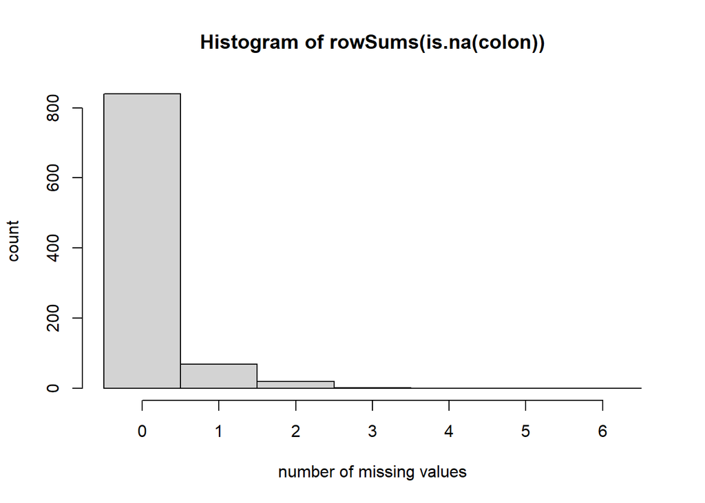

```r
hist(rowSums(is.na(colon)),breaks=seq(-0.5,6.5),xlab="number of missing values",ylab="count")
```

From this it’s hard to tell any stucture of missingness, so need to do further EDA and cleaning.

```r
library(VIM)
```

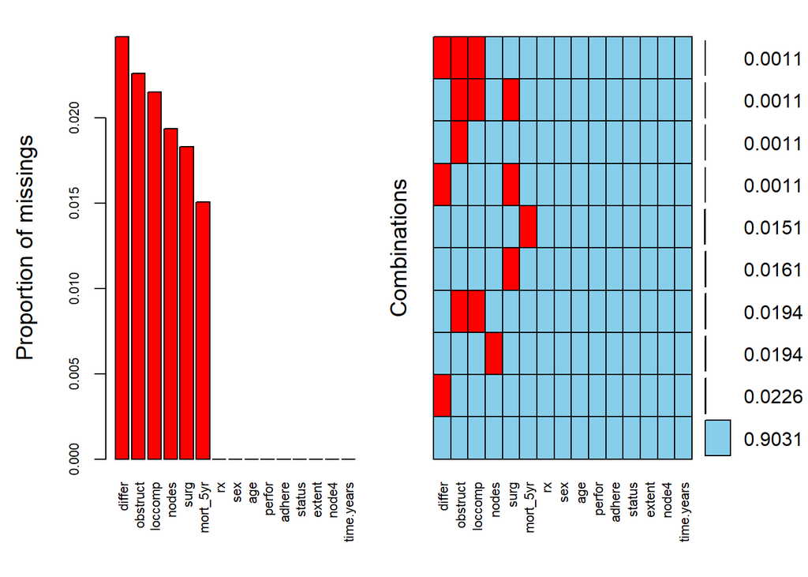

```
##
##  Variables sorted by number of missings:
##    Variable      Count
##      differ 0.02475780
##    obstruct 0.02260495
##     loccomp 0.02152853
##       nodes 0.01937567
##        surg 0.01829925
##    mort_5yr 0.01506997
##          rx 0.00000000
##         sex 0.00000000
##         age 0.00000000
##      perfor 0.00000000
##      adhere 0.00000000
##      status 0.00000000
##      extent 0.00000000
##       node4 0.00000000
##  time.years 0.00000000
```

```r
aggr(colon, numbers = TRUE, sortVars = TRUE, labels = names(colon), cex.axis = 0.7, gap = 3)
```

From these graphs it is clear to see that any missingness in the dataframe only comes from the six variables:“differ”, “obstruct”, “loccomp”, “nodes”, “surg” and “mort_5yr”.

Unfortunately, with missing data comes induced bias, innacurate and missleading results. In order to present data for an anonymised health data competition, missingness needs to be address along with further cleaning.

To “fill in” the missingness, different imputations can be performed to replace missing values with estimations. The use of imputations preserve the struture of the data, rather than cleaning by removing too many values and variables. Multiple imputation styles are performed below, eahc having a different effect on further anyalysis. The question is, which avenue to go down for “tidying up the data”?

It is also important that when considering imputations for dataframes, that the distribution stays similar to that before the imputation. Thus it makes sense to plot the original distributions for the variables with missing data.

We note that colnames(colon) include variables that we expect to be strongly correlated, such as nodes and node4. That is a problem for primary inference but is a benefit for imputation…!

Its worth noting that one of the variables we predicted was mort_5yr; this a) bodes well for prediction, and b) could be dangerous if we use imputed values to truth our findings!

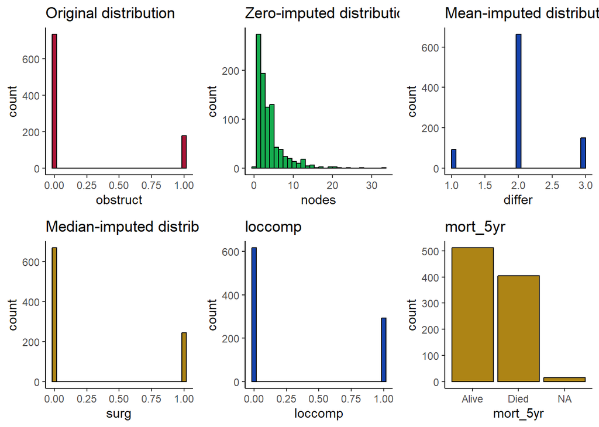

```r
library(ggplot2)
library(dplyr)
library(cowplot)
h1 <- ggplot(colon, aes(obstruct)) +
  geom_histogram(fill = "#ad1538", color = "#000000", position = "identity") +
  ggtitle("Original distribution") +
  theme_classic()
h2 <- ggplot(colon, aes(nodes)) +
  geom_histogram(fill = "#15ad4f", color = "#000000", position = "identity") +
  ggtitle("Zero-imputed distribution") +
  theme_classic()
h3 <- ggplot(colon, aes(differ)) +
  geom_histogram(fill = "#1543ad", color = "#000000", position = "identity") +
  ggtitle("Mean-imputed distribution") +
  theme_classic()
h4 <- ggplot(colon, aes(surg)) +
  geom_histogram(fill = "#ad8415", color = "#000000", position = "identity") +
  ggtitle("Median-imputed distribution") +
  theme_classic()
h5 <- ggplot(colon, aes(loccomp)) +
  geom_histogram(fill = "#1543ad", color = "#000000", position = "identity") +
  ggtitle("loccomp") +
  theme_classic()
h6 <- ggplot(colon, aes(mort_5yr)) +
  geom_histogram(fill = "#ad8415", color = "#000000", position = "identity", stat="count") +
  ggtitle("mort_5yr") +
  theme_classic()
plot_grid(h1, h2, h3, h4,h5, h6, nrow = 2, ncol = 3)
```

Unfortunately since most of the variables are binary, there’s little insight from their distributions. However we could still draw a comparison for how each imputation dealt with the nodes variable…

##2.1 KNN imputation

We can perform KNN imputation, that involves replacing any missing values with the value of the K-nearest neighbour, this is a metric based on local distances.

Note here, the kNN is a K-Nearest Neighbour imputation based on a variation of the Gower Distance, rather than the SVD imputation in the lecture notes, due to the binary variables we are trying to impute, alongside categorical factors.

```r
#install.packages("VIM")

library(VIM)


imputed_knn <- kNN(colon, k=5) #here we take a default of k=5
imputed_knn = imputed_knn[-(16:30)]

head(imputed_knn)
```

```
##        rx sex age obstruct perfor adhere nodes status differ extent surg node4
## 1 Lev+5FU   1  43        0      0      0     5      1      2      3    0     1
## 2 Lev+5FU   1  63        0      0      0     1      0      2      3    0     0
## 3     Obs   0  71        0      0      1     7      1      2      2    0     1
## 4 Lev+5FU   0  66        1      0      0     6      1      2      3    1     1
## 5     Obs   1  69        0      0      0    22      1      2      3    1     1
## 6 Lev+5FU   0  57        0      0      0     9      1      2      3    0     1
##   loccomp time.years mort_5yr
## 1       0  4.1671233     Died
## 2       0  8.4575342    Alive
## 3       1  2.6383562     Died
## 4       1  0.8027397     Died
## 5       0  1.8054795     Died
## 6       0  4.8410959     Died
```

```r
#Checking no more NAs
#table(is.na(imputed_knn))
```

##2.3 Regression imputation Regression can be used where there is a correlation between variables within the data set, where one variable could predict the outcome for another variable. From a brief glance of the dataset, there seems to be some correlation between variables and thus there is potential for a regression imputation. Where correlation is significant.

```r
allpresent=colnames(colon)[colSums(is.na(colon))==0] # columns with no missingness
allpresent=allpresent[allpresent!="anymissing"]


missingcols=colnames(colon)[colSums(is.na(colon))>0] # columns with no missingness
train=sample(1:dim(colon)[1])[1:700] # training data
test=(1:dim(colon)[1])[!(1:dim(colon)[1])%in%train] # 229 reserved for training...
#sapply(missingcols,function(x)length(table(colon[ttest,x])))

## correlation scores
allscores=c() #
allclasses=c() # correlation classes
colonimp=colon
for(v in missingcols){
  ttest=test[!is.na(colon[test,v])] # get the subset of available values
  tmiss=which(is.na(colon[,v])) # A list of missing data in this column
  isbinary=length(table(colon[ttest,v]))==2 # whether this variable is a binary variable or not
  if(isbinary){
      tmodel=glm(paste(v,"~",paste(allpresent,collapse="+"),collapse=""),
                      data=colon[train,c(v,allpresent)],family = binomial)
  }else{
    tmodel=lm(paste(v,"~",paste(allpresent,collapse="+"),collapse=""),
                      data=colon[train,c(v,allpresent)])
  }
  ## glm will automatically omit missing data in the training data
  tpred=predict(tmodel,newdata=colon[ttest,],type="response") # For performance evaluation, predicting the test data
  tscore=cor(as.numeric(colon[ttest,v]),tpred) ## We will use correlation as a score
  names(isbinary)=names(tscore)=v # annoyingly R loses the names so we put the name on manually
  print(paste("Correlation between observed and prediction for column",v,"=",tscore))
  allscores=c(allscores,tscore)
  allclasses=c(allclasses,isbinary)
  ## Now we have scores, we'll apply the prediction to the unseen data
  tpredimpute=predict(tmodel,newdata=colon[tmiss,,drop=FALSE],type="response") # For imputation
  if(tscore>0.6){ # If imputation is good enough, use it
    if(isbinary){
      if(is.factor(colonimp[,v])){
        colonimp[tmiss,v]=levels(colonimp[tmiss,v])[1+round(tpredimpute)]
      }else {
        colonimp[tmiss,v]=round(tpredimpute)
      }
    }else{
      colonimp[tmiss,v]=tpredimpute
    }
  }
}
```

```
## [1] "Correlation between observed and prediction for column obstruct = 0.065270834312232"
## [1] "Correlation between observed and prediction for column nodes = 0.784192053306583"
## [1] "Correlation between observed and prediction for column differ = 0.173388892503024"
## [1] "Correlation between observed and prediction for column surg = 0.025375619251427"
## [1] "Correlation between observed and prediction for column loccomp = 0.679899529570157"
## [1] "Correlation between observed and prediction for column mort_5yr = 0.96399502168163"
```

```r
c("cols with missingness"=sum(colSums(apply(colon,2,is.na))>0),
  "after imputation"=sum(colSums(apply(colonimp,2,is.na))>0))
```

```
## cols with missingness      after imputation
##                     6                     3
```

Since regression only applicable to variables with significant correlation score, further imputations are still required. Here we could perform an additional kNN imputation to fill in the further missing errors for the final three variables. Which is necessary where some variables are catergorical…

```r
imputed_regknn <- kNN(colonimp, k=5) #here we take a default of k=5
imputed_regknn = imputed_knn[-(16:30)]

head(imputed_regknn)
```

```
##        rx sex age obstruct perfor adhere nodes status differ extent surg node4
## 1 Lev+5FU   1  43        0      0      0     5      1      2      3    0     1
## 2 Lev+5FU   1  63        0      0      0     1      0      2      3    0     0
## 3     Obs   0  71        0      0      1     7      1      2      2    0     1
## 4 Lev+5FU   0  66        1      0      0     6      1      2      3    1     1
## 5     Obs   1  69        0      0      0    22      1      2      3    1     1
## 6 Lev+5FU   0  57        0      0      0     9      1      2      3    0     1
##   loccomp time.years mort_5yr
## 1       0  4.1671233     Died
## 2       0  8.4575342    Alive
## 3       1  2.6383562     Died
## 4       1  0.8027397     Died
## 5       0  1.8054795     Died
## 6       0  4.8410959     Died
```

```r
#Checking no more NAs
#table(is.na(imputed_regknn))
```

## 2.4 Random forest imputation

The Miss Forest imputation technique is based on the Random Forest algorithm. It’s a non-parametric imputation method, which means it doesn’t make explicit assumptions about the function form, but instead tries to estimate the function in a way that’s closest to the data points.

In other words, it builds a random forest model for each variable and then uses the model to predict missing values. You can learn more about it by reading the article by Oxford Academic.

```r
#install.packages("missForest")
library(missForest)
forest_imputation = missForest(colon)$ximp
head(forest_imputation)
```

```
##        rx sex age      obstruct perfor adhere nodes status differ extent surg
## 1 Lev+5FU   1  43 -6.902812e-16      0      0     5      1      2      3    0
## 2 Lev+5FU   1  63  0.000000e+00      0      0     1      0      2      3    0
## 3     Obs   0  71  0.000000e+00      0      1     7      1      2      2    0
## 4 Lev+5FU   0  66  1.000000e+00      0      0     6      1      2      3    1
## 5     Obs   1  69  0.000000e+00      0      0    22      1      2      3    1
## 6 Lev+5FU   0  57  0.000000e+00      0      0     9      1      2      3    0
##   node4    loccomp time.years mort_5yr
## 1     1 0.03880952  4.1671233     Died
## 2     0 0.00000000  8.4575342    Alive
## 3     1 1.00000000  2.6383562     Died
## 4     1 1.00000000  0.8027397     Died
## 5     1 0.00000000  1.8054795     Died
## 6     1 0.00000000  4.8410959     Died
```

```r
# Checking no more NAs
#table(is.na(forest_imputation))
```

## 3.1 Imputation comparison

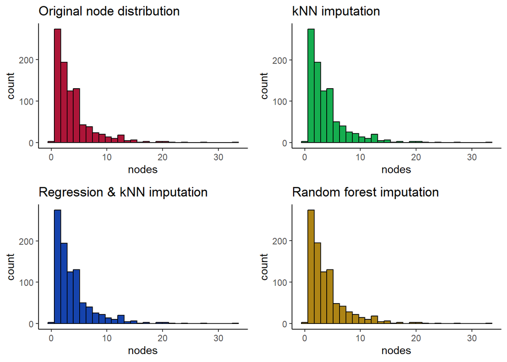

```r
h1 <- ggplot(colon, aes(nodes)) +
  geom_histogram(fill = "#ad1538", color = "#000000", position = "identity") +
  ggtitle("Original node distribution") +
  theme_classic()
h2 <- ggplot(imputed_knn, aes(nodes)) +
  geom_histogram(fill = "#15ad4f", color = "#000000", position = "identity") +
  ggtitle("kNN imputation") +
  theme_classic()
h3 <- ggplot(imputed_regknn, aes(nodes)) +
  geom_histogram(fill = "#1543ad", color = "#000000", position = "identity") +
  ggtitle("Regression & kNN imputation") +
  theme_classic()
h4 <- ggplot(forest_imputation, aes(nodes)) +
  geom_histogram(fill = "#ad8415", color = "#000000", position = "identity") +
  ggtitle("Random forest imputation") +
  theme_classic()

plot_grid(h1, h2, h3, h4, nrow = 2, ncol = 2)
```

From the distribtions of the nodes vairable after each imputation, it is clear to see none of the imputations cause drastic changes to the distribution (which is always a good thing). With all plots being extremely close to the original distribution for nodes, there is no clear best choice for imputation on the node variable.

However, due to complexity of relationships between vairables (where some relationships aren’t linear) it makes sense to favour the knn model or random forest model over the regression model (that relies highly on linear relationships).

## 4.1 EDA and tidying

Removing duplicate factors & observations where NA occurs for target variable ‘mort_5yr’.

```r
colon = as.data.frame(colon_s)[,-1] # remove the "id" column
colon=colon[,-grep("factor",colnames(colon))]
colon=colon[,!colnames(colon)%in%"mort_5yr.num"] # keep mort_5yr
colon=colon[,c(1:12,14:16)]
colon = colon[-which(is.na(colon$mort_5yr)),]
# checking no more NA's in new colon for the target variable mort_5yr
# sum(is.na(colon$mort_5yr))
```

```r
table(is.na(colon))
```

```
##
## FALSE  TRUE
## 13626    99
```

Imputing missing data using kNN imputation (note could’ve used random forest but data sufficiently small for kNN).

```r
imputed_knn <- kNN(colon, k=5) #here we take a default of k=5
imputed_knn = imputed_knn[-(16:30)]

head(imputed_knn)
```

```
##        rx sex age obstruct perfor adhere nodes status differ extent surg node4
## 1 Lev+5FU   1  43        0      0      0     5      1      2      3    0     1
## 2 Lev+5FU   1  63        0      0      0     1      0      2      3    0     0
## 3     Obs   0  71        0      0      1     7      1      2      2    0     1
## 4 Lev+5FU   0  66        1      0      0     6      1      2      3    1     1
## 5     Obs   1  69        0      0      0    22      1      2      3    1     1
## 6 Lev+5FU   0  57        0      0      0     9      1      2      3    0     1
##   loccomp time.years mort_5yr
## 1       0  4.1671233     Died
## 2       0  8.4575342    Alive
## 3       1  2.6383562     Died
## 4       1  0.8027397     Died
## 5       0  1.8054795     Died
## 6       0  4.8410959     Died
```

```r
table(is.na(imputed_knn))
```

```
##
## FALSE
## 13725
```

After performing the kNN imputation, it is also important to note the ‘node4’ is the variable for “more than 4 postivie lymph nodes”, whilst ‘nodes’ is “number of lymph nodes with detectable cancer”, thus after we have essentially used node4 to perform an imputation on nodes. There is a clear relationship to node4 = 0, when nodes <4, and when node=1, nodes => 4, this implies another “duplicate” variable that wont provide any insight into inferences. Thus we can remode the node4, for a “tidier” dataset.

```r
imputed_knn = imputed_knn[-12]
```

The remove constant function removes low variance variables which if present wouldn’t show any significant relationship to the ‘mort_5yr’ variable, due to almost constant variable.

```r
library(janitor)
colon <- imputed_knn %>%
remove_constant()
head(colon)
```

```
##        rx sex age obstruct perfor adhere nodes status differ extent surg
## 1 Lev+5FU   1  43        0      0      0     5      1      2      3    0
## 2 Lev+5FU   1  63        0      0      0     1      0      2      3    0
## 3     Obs   0  71        0      0      1     7      1      2      2    0
## 4 Lev+5FU   0  66        1      0      0     6      1      2      3    1
## 5     Obs   1  69        0      0      0    22      1      2      3    1
## 6 Lev+5FU   0  57        0      0      0     9      1      2      3    0
##   loccomp time.years mort_5yr
## 1       0  4.1671233     Died
## 2       0  8.4575342    Alive
## 3       1  2.6383562     Died
## 4       1  0.8027397     Died
## 5       0  1.8054795     Died
## 6       0  4.8410959     Died
```

Note here, no low variance variables so dataset is the same.

For the final dataset presented for further research in an anonymised health data competition, since id was equal to index, it is important to “shuffle” the row names of the final dataset, so no id could be extracted from its relationship to row names that would reveal any identity.

```r
rownames(colon) <- sample(nrow(colon))
head(colon)
```

```
##          rx sex age obstruct perfor adhere nodes status differ extent surg
## 37  Lev+5FU   1  43        0      0      0     5      1      2      3    0
## 322 Lev+5FU   1  63        0      0      0     1      0      2      3    0
## 375     Obs   0  71        0      0      1     7      1      2      2    0
## 896 Lev+5FU   0  66        1      0      0     6      1      2      3    1
## 88      Obs   1  69        0      0      0    22      1      2      3    1
## 570 Lev+5FU   0  57        0      0      0     9      1      2      3    0
##     loccomp time.years mort_5yr
## 37        0  4.1671233     Died
## 322       0  8.4575342    Alive
## 375       1  2.6383562     Died
## 896       1  0.8027397     Died
## 88        0  1.8054795     Died
## 570       0  4.8410959     Died
```